# 251019566

Daniel Gonçalves Gomes Ferreira

2025-05-17

# Exercício 1:

```r
MaxOverall = max(ANALISEfifa21$overall)
MinPotential = min(ANALISEfifa21$potential)
summary(ANALISEfifa21)
```

```
##    player_id          name           nationality          position
##  Min.   :    41   Length:17981       Length:17981       Length:17981
##  1st Qu.:204881   Class :character   Class :character   Class :character
##  Median :226753   Mode  :character   Mode  :character   Mode  :character
##  Mean   :220913
##  3rd Qu.:241587
##  Max.   :256469
##     overall           age             hits           potential
##  Min.   :56.00   Min.   :17.00   Min.   :  0.000   Min.   :57.00
##  1st Qu.:63.00   1st Qu.:23.00   1st Qu.:  0.000   1st Qu.:67.00
##  Median :67.00   Median :26.00   Median :  0.000   Median :71.00
##  Mean   :67.27   Mean   :26.31   Mean   :  2.689   Mean   :71.74
##  3rd Qu.:71.00   3rd Qu.:30.00   3rd Qu.:  2.000   3rd Qu.:76.00
##  Max.   :94.00   Max.   :43.00   Max.   :371.000   Max.   :95.00
##      team
##  Length:17981
##  Class :character
##  Mode  :character
##
##
##
```

```r
#CÓDIGOS USADOS DENTRO DO TEXTO: `r MaxOverall`, `r MinPotential`
```

Dessa forma, a maior classificação geral pertence ao jogador com **94** de *Overall*.

E os jogadores com menor potencial tem **57** de *Potential*

# Exercício 2:

```r
best_players = ANALISEfifa21[ANALISEfifa21$overall >= 90,]
NomeMaxOverall = filter(ANALISEfifa21, overall == MaxOverall )

#CÓDIGOS USADOS DENTRO DO TEXTO:`r NomeMaxOverall$name`, `r MaxOverall`,`r best_players$name`

#COMENTÁRIO: alterar a fonte e cor do texto exibido com a saída:html <span style="font-size: px; color: red;">`r best_players$name`.</span>
```

O jogador com a maior classificação é o: **Lionel Messi** tendo **94** de classificação geral.

E os jogadores com a classificação geral acima de 90 são: **Cristiano Ronaldo, Sergio Agüero, Lionel Messi, Eden Hazard, Robert Lewandowski, Neymar Jr, Marc-André ter Stegen, Kevin De Bruyne, Jan Oblak, Virgil van Dijk, Sadio Mané, Mohamed Salah, Alisson**.

# Exercício 3:

```r
ExisteSemTime = any(is.na(ANALISEfifa21$team))
QuantidadeSemTime = nrow(which(is.na(ANALISEfifa21$team)))

#CÓDIGO USADO PARA O TEXTO: `r if (!ExisteSemTime) {"Não tem jogadores sem time"} else {paste("Existe", QuantidadeSemTime, "de jogadores sem time")}`
```

Não existe jogadores sem time

# Exercício 4:

```r
worst_potential = filter(ANALISEfifa21, potential == MinPotential )

#CÓDIGO USADO PARA O TEXTO:`r worst_potential$name`
```

OS jogadores com o pior potencial são: **Kyriakos Stamatopoulos, Nicky Hunt, Alan Bennett, Rene Gilmartin, Li Benjian, Luka Mijaljevic, Alex Cooper, Adam Buxton, Dominik Budzynski, Jacob Blyth, Mohammed Al Wakid, Marc Mas, Zhu Xiaogang, Sun Le, Wang Dalong, Qiao Wei, Wang Guoming, Jiang Wenjun, Wang Weilong, Tong Xiaoxing, Song Zhiwei, Mu Pengfei, Jesse Weißenfels, Dhwanil Singhal, Bernaldo Manzano, Mousa Zoulan, Bryan Mendoza, Enzo Díaz, Carlos Orejuela, Carlos Canales, Maximiliano Quinteros, Hassan Al Shamrani**

# Exercício 5:

```r
ANALISEfifa21$team = replace(ANALISEfifa21$team,ANALISEfifa21$potential == min(ANALISEfifa21$potential), NA)

ANALISEfifa21[which(is.na(ANALISEfifa21$team)),c("name","team")]
```

```
##                         name team
## 66    Kyriakos Stamatopoulos <NA>
## 156               Nicky Hunt <NA>
## 291             Alan Bennett <NA>
## 979           Rene Gilmartin <NA>
## 1409              Li Benjian <NA>
## 3241         Luka Mijaljevic <NA>
## 4168             Alex Cooper <NA>
## 4360             Adam Buxton <NA>
## 5633       Dominik Budzynski <NA>
## 5739             Jacob Blyth <NA>
## 7298       Mohammed Al Wakid <NA>
## 7391                Marc Mas <NA>
## 7814            Zhu Xiaogang <NA>
## 8479                  Sun Le <NA>
```

[output cut: 18 more lines]

# Exercício 6:

```r
Laterais = filter(ANALISEfifa21, position == "LB" | position == "RB" )
QntdLaterais = nrow(Laterais)

#CÓDIGO USADO PARA O TEXTO:`r QntdLaterais`
```

Existem **1301** de jogadores que jogam na posição LB ou RB

# Exercício 7:

```r
brazil21 = ANALISEfifa21[ANALISEfifa21$nationality == "Brazil",]
spain21 = ANALISEfifa21[ANALISEfifa21$nationality == "Spain",]
```

# Exercício 8:

```r
QntdBrasil = nrow(brazil21)
QntdEspanha = nrow(spain21)

#CÓDIGO USADO PARA O TEXTO: `r QntdBrasil`,`r QntdEspanha`
```

O Brasil possui **894** de jogadores no banco de dados A Espanha possui **1055** de jogadores no banco de dados

# Exercício 9:

```r
MediaGeralBR = mean(brazil21$overall,)
MediaGeralEspanha = mean(spain21$overall,)

#CÓDIGO USADO PARA O TEXTO:`r MediaGeralBR`, `r MediaGeralEspanha`
```

A média geral dos jogadores do Brasil é de **71.4228188**. A média geral dos jogadores da Espanha é de **69.8748815**.

# Exercício 10:

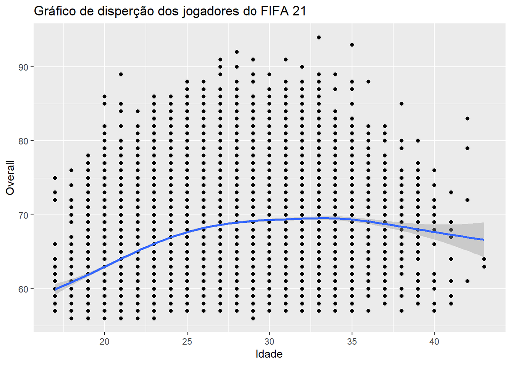

```r
ggplot(ANALISEfifa21,aes(age,overall))+
  geom_point() +
  geom_smooth() +
  labs(title = "Gráfico de disperção dos jogadores do FIFA 21",
       x = "Idade",
       y = "Overall")
```

Ao analisar o intervalo de **27 a 35 anos**, é possivel observar uma grande densidade de jogadores com classificação alta e um grande numero de pontos outlines, inferindo que esse seja o auge da carreira do jogador. De maneira análoga, os jogares que aparecem fora desse intervalo com pontos outlines se destacam por sua qualidade individual.